# Data/results not shown in dental research papers - analysis

Eero Raittio, Ahmad Sofi-Mahmudi

2022-02-10

# Download and unpack data folder

# Loading required packages (after install of pacman package)

```r
#install.packages("pacman")
library(pacman)
p_load(tidyverse,lubridate, ggplot2,ggpubr,data.table, gtsummary)
```

# Loading the datasets

First, set working directory to the folder that has all the datasets in it using setwd() function and then run the following codes:

```r
db_all <- read.csv("data/db_all.csv")

db_dns <- read.csv("data/db_dns.csv")

hits_med_all <- read.csv("data/hits_med_all.csv")

hits_med_dns <- read.csv("data/hits_med_dns.csv")
```

# Results

## Overall perspective

Total number of papers in dental journals in all time:

```
##   number_of_papers number_of_journals
## 1            21217                116
```

Number of papers with “data/results not shown”:

```
##   number_of_papers nummber_of_journals
## 1             1474                  70
```

## Figures

First, adding the real publication year to the datasets. The real publication year is the year the paper was first appear online stored in firstPublicationDate column.

```r
db_all <- db_all %>%
  mutate(year_firstpub = year(
    as.POSIXlt(firstPublicationDate,
               format = "%Y-%m-%d")
  ))

db_dns <- db_dns %>%
  mutate(year_firstpub = year(
    as.POSIXlt(firstPublicationDate,
               format = "%Y-%m-%d")
  ))
```

Figure 1A (dental plot)

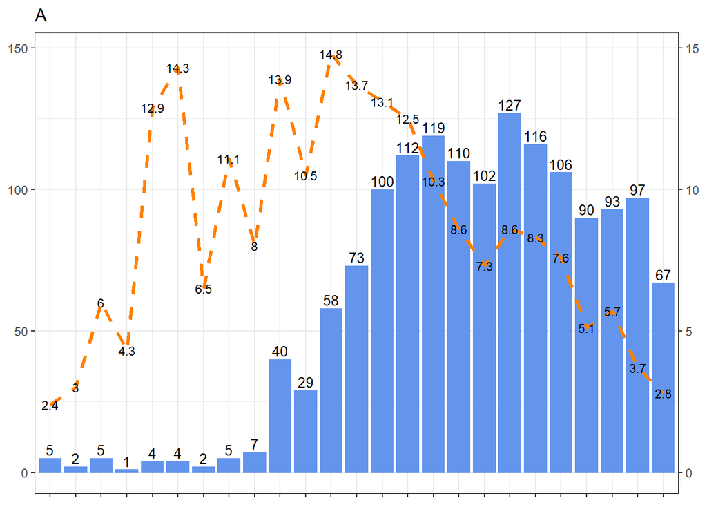

```r
trend_dent <- merge(count(db_dns, year_firstpub), count(db_all, year_firstpub), by = "year_firstpub")

colnames(trend_dent) <- c("year_firstpub", "data_not_shown", "all_fulltexts")

trend_dent <- mutate(trend_dent, pubYear_modified =
                       ifelse(year_firstpub < 1990, "< 1990",
                     ifelse((year_firstpub >= 1990) & (year_firstpub < 1995), "1990 - 1994",
                     ifelse((year_firstpub >= 1995) & (year_firstpub < 2000), "1995 - 1999",
                     year_firstpub))))


trend_dent <- trend_dent %>%
  group_by(pubYear_modified) %>%
  summarise(data_not_shown = sum(data_not_shown),
            all_fulltexts = sum(all_fulltexts)) %>%
  mutate(percentage = round(data_not_shown/all_fulltexts*100, 1))


plot_dent <- trend_dent %>%
  ggplot() +
  geom_col(aes(x = pubYear_modified,
               y = data_not_shown),
           size = 1,
           fill = "cornflowerblue") +
  geom_line(aes(x = pubYear_modified,
                y = 10*percentage),
            size = 1.2,
            color="darkorange1",
            linetype=2,group = 1) +
  geom_text(aes(label = data_not_shown,
                x = pubYear_modified,
                y = data_not_shown+3),
            color = "black",
            size = 3.5) +
  geom_text(aes(label = percentage,
                x = pubYear_modified,
                y = 10*percentage),
            color = "black",
            size=3) +
  scale_y_continuous(sec.axis = sec_axis(~./10)) +
  theme_bw() +
  theme(axis.title.x=element_blank(), axis.text.x = element_blank()) +
  theme(axis.title.y=element_blank()) +
  labs(title = "A", x = "Year")


plot_dent
```

Figure 1B (medical plot):

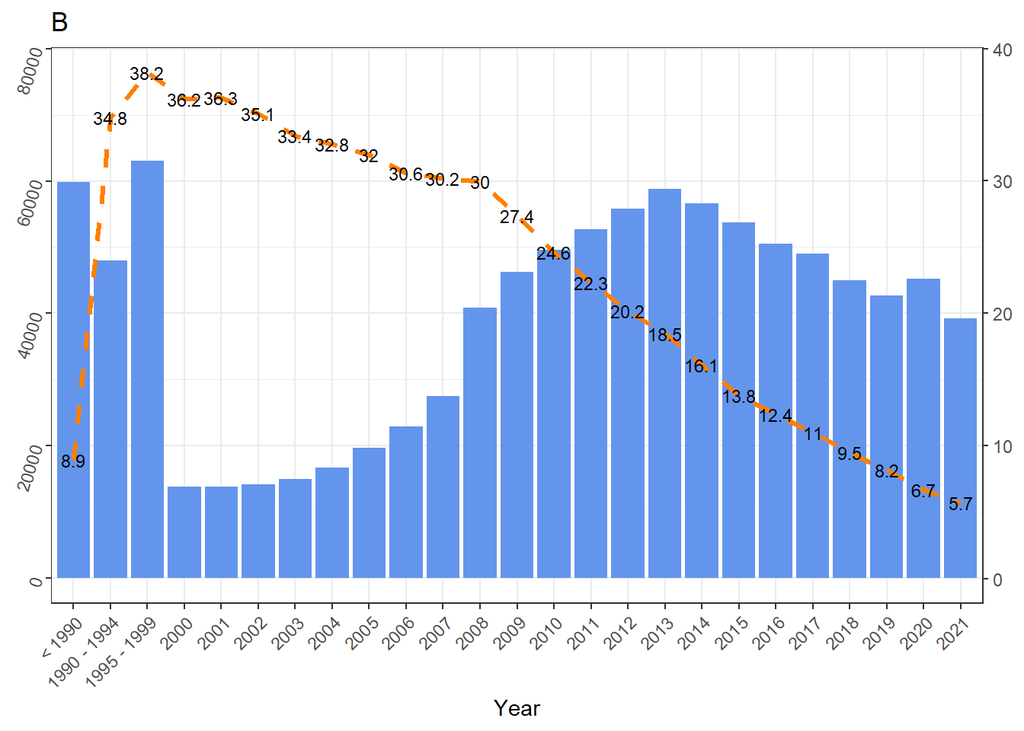

```r
trend_med <- merge(hits_med_dns, hits_med_all, by = c("year"))
trend_med <- trend_med[, -c(2, 3, 5, 6)]
colnames(trend_med) <- c("pubYear", "data_not_shown", "all_fulltexts")

trend_med <- mutate(trend_med, pubYear_modified =
                       ifelse(pubYear < 1990, "< 1990",
                     ifelse((pubYear >= 1990) & (pubYear < 1995), "1990 - 1994",
                     ifelse((pubYear >= 1995) & (pubYear < 2000), "1995 - 1999",
                     pubYear))))


trend_med <- trend_med %>%
  group_by(pubYear_modified) %>%
  summarise(data_not_shown = sum(data_not_shown),
            all_fulltexts = sum(all_fulltexts)) %>%
  mutate(percentage = round(data_not_shown/all_fulltexts*100, 1))


plot_med <- trend_med %>%
  ggplot() +
  geom_col(aes(x = pubYear_modified,
               y = data_not_shown),
           size = 1,
           fill = "cornflowerblue") +
  geom_line(aes(x = pubYear_modified,
                y = 2000*percentage),
            size = 1.2,
            color="darkorange1",
            linetype=2,group = 1) +
  geom_text(aes(label = percentage,
                x = pubYear_modified,
                y = 2000*percentage),
            color = "black",
            size=3) +
  scale_y_continuous(sec.axis = sec_axis(~./2000)) +
  guides(x =  guide_axis(angle = 45), y = guide_axis(angle = 74)) +
  theme_bw() +
  theme(axis.title.y=element_blank()) +
  labs(title = "B", x = "Year")


plot_med
```

Combining plots:

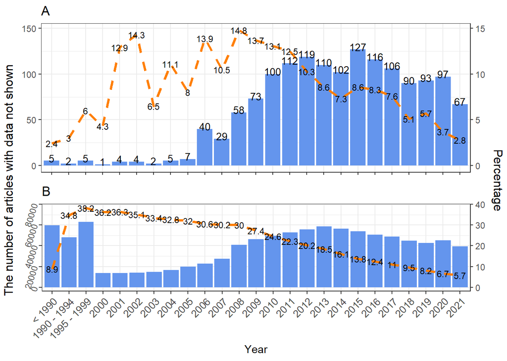

```r
figure <- ggarrange(plot_dent, plot_med + font("x.text", size = 10),
                    ncol = 1, nrow = 2)

anfig <- annotate_figure(figure,
                left = text_grob("The number of articles with data not shown", color = "black", rot = 90),
                right = "Percentage",
)


# tiff("Figure.tif", units = "cm", height = 31, width = 20, res = 300)
anfig
```

```r
# dev.off()
```

## 2021 perspective

Total hits and journals for 2021:

```r
data.frame(total_hits = nrow(
  filter(db_all,
         grepl("2021", firstPublicationDate))),
           total_journals = length(
  unique(
  filter(db_all,
         grepl("2021",
               firstPublicationDate))
  $journalTitle))

           )
```

```
##   total_hits total_journals
## 1       2434             73
```

For analysing publishers, we’ll load publishers dataset:

```r
publishers <- read.csv("data/publishers.csv")
```

Join publishers to dataframes:

```r
db_all <- merge(db_all, publishers, by.x = "journalTitle", by.y = "ï..Journal", all.x = T)

db_dns <- merge(db_dns, publishers, by.x = "journalTitle", by.y = "ï..Journal", all.x = T)
```

Number of papers, journals and publishers that published papers with “data/results not shown” in 2021:

```r
data.frame(
  total_papers = nrow(filter(db_dns, grepl("2021", firstPublicationDate))),
  percentage = round(nrow(filter(db_dns, grepl("2021", firstPublicationDate)))/nrow(filter(db_all, grepl("2021", firstPublicationDate)))*100, 1),
  total_journals = length(unique(filter(db_dns, grepl("2021", firstPublicationDate))$journalTitle)),
  total_publishers = length(unique(filter(db_dns, grepl("2021", firstPublicationDate))$Publons))
)
```

```
##   total_papers percentage total_journals total_publishers
## 1           67        2.8             22                8
```

Journal-related differences in publishing data not shown papers in 2021:

```r
db_dns$datanotshown = 1
db_total = merge(db_all,db_dns,all=T)
db_total$datanotshown = ifelse(is.na(db_total$datanotshown),0,db_total$datanotshown)
db_total  %>% filter(firstPublicationDate %like% "2021") %>% select(datanotshown,journalTitle) %>%
  tbl_summary(by=journalTitle, label = list(datanotshown ~ "Data not shown")) %>% add_p(test.args=all_tests("fisher.test") ~ list(simulate.p.value=TRUE))%>%
        as_flex_table()
```

| Characteristic | Am J Orthod Dentofacial Orthop, N = 111 | Anesth Prog, N = 241 | Angle Orthod, N = 1171 | Arch Oral Biol, N = 11 | BMC Oral Health, N = 6961 | Br Dent J, N = 2141 | Br J Oral Maxillofac Surg, N = 141 | Can J Dent Hyg, N = 201 | Caries Res, N = 61 | Cleft Palate Craniofac J, N = 81 | Clin Exp Dent Res, N = 841 | Clin Implant Dent Relat Res, N = 91 | Clin Oral Implants Res, N = 161 | Clin Oral Investig, N = 1471 | Community Dent Oral Epidemiol, N = 51 | Compend Contin Educ Dent, N = 11 | Dent Mater, N = 31 | Dent Mater J, N = 11 | Dent Traumatol, N = 41 | Dental Press J Orthod, N = 571 | Dentomaxillofac Radiol, N = 21 | Eur Arch Paediatr Dent, N = 221 | Eur Endod J, N = 251 | Eur J Dent Educ, N = 71 | Eur J Oral Sci, N = 81 | Eur J Orthod, N = 131 | Evid Based Dent, N = 221 | Facial Plast Surg, N = 21 | Gerodontology, N = 41 | … |
| --- | --- | --- | --- | --- | --- | --- | --- | --- | --- | --- | --- | --- | --- | --- | --- | --- | --- | --- | --- | --- | --- | --- | --- | --- | --- | --- | --- | --- | --- | --- |
| Data not shown | 0 (0%) | 0 (0%) | 1 (0.9%) | 0 (0%) | 24 (3.4%) | 0 (0%) | 1 (7.1%) | 0 (0%) | 0 (0%) | 0 (0%) | 3 (3.6%) | 0 (0%) | 0 (0%) | 3 (2.0%) | 0 (0%) | 0 (0%) | 0 (0%) | 0 (0%) | 0 (0%) | 0 (0%) | 0 (0%) | 0 (0%) | 0 (0%) | 0 (0%) | 0 (0%) | 0 (0%) | 0 (0%) | 0 (0%) | 0 (0%) | … |

1n (%)  
2Fisher's Exact Test for Count Data with simulated p-value (based on 2000 replicates)

Publisher-related differences in publishing data not shown papers in 2021 (based on Publons):

```r
db_total  %>% filter(firstPublicationDate %like% "2021") %>% select(datanotshown,Publons) %>%
  tbl_summary(by=Publons, label = list(datanotshown ~ "Data not shown")) %>% add_p(test.args=all_tests("fisher.test") ~ list(simulate.p.value=TRUE))%>%
        as_flex_table()
```

```
## 182 observations missing `Publons` have been removed. To include these observations, use `forcats::fct_explicit_na()` on `Publons` column before passing to `tbl_summary()`.
```

| Characteristic | Allen Press Inc., N = 1411 | American Dental Association, N = 441 | Churchill Livingstone, N = 161 | Dental Learning Systems Co., Inc., N = 11 | Dental Press International, N = 571 | Elsevier, N = 231 | Faculdade de Odontologia de Bauru, N = 701 | Japanese Association for Oral Biology, N = 11 | KARE Publishing, N = 251 | Karger Publishers, N = 61 | Mosby Inc., N = 151 | Nature Publishing Group, N = 2361 | Oxford University Press, N = 131 | SAGE Publishing, N = 591 | Sichuan yi xue yuan, N = 911 | Springer, N = 221 | Springer Nature, N = 1,1361 | W.B. Saunders Ltd, N = 171 | Wiley, N = 3091 | Wolters Kluwer Health \| Lippincott, N = 371 | p-value2 |
| --- | --- | --- | --- | --- | --- | --- | --- | --- | --- | --- | --- | --- | --- | --- | --- | --- | --- | --- | --- | --- | --- |
| Data not shown | 1 (0.7%) | 3 (6.8%) | 1 (6.2%) | 0 (0%) | 0 (0%) | 0 (0%) | 6 (8.6%) | 0 (0%) | 0 (0%) | 0 (0%) | 0 (0%) | 0 (0%) | 0 (0%) | 3 (5.1%) | 0 (0%) | 0 (0%) | 36 (3.2%) | 0 (0%) | 15 (4.9%) | 0 (0%) | 0.004 |

1n (%)  
2Fisher's Exact Test for Count Data with simulated p-value (based on 2000 replicates)

Fisher’s exact test for publisher-related differences in publishing data not shown papers in 2021 (based on NLM Catalog):

```r
db_total  %>% filter(firstPublicationDate %like% "2021") %>% select(datanotshown,NLMCatalog) %>%
  tbl_summary(by=NLMCatalog, label = list(datanotshown ~ "Data not shown")) %>% add_p(test.args=all_tests("fisher.test") ~ list(simulate.p.value=TRUE))%>%
        as_flex_table()
```

```
## 182 observations missing `NLMCatalog` have been removed. To include these observations, use `forcats::fct_explicit_na()` on `NLMCatalog` column before passing to `tbl_summary()`.
```

| Characteristic | American Academy of Periodontology, N = 71 | American Assn. of Dental Schools, N = 301 | American Dental Assn, N = 331 | American Dental Assocation, N = 21 | American Dental Association, N = 531 | American Dental Society of Anesthesiology, N = 241 | B.C. Decker, N = 461 | BC Decker, N = 11 | Beech Hill Pub. Co., N = 41 | BioMed Central, N = 7481 | Blackwell Pub, N = 81 | Blackwell Scientific Publications, N = 201 | British Dental Journal, N = 221 | C.V. Mosby, N = 111 | Churchill Livingstone, N = 271 | Dental Learning Systems, N = 11 | Dental Press International, N = 571 | Edward H. Angle Society of Orthodontia, N = 1171 | Elsevier, N = 11 | Elsevier Masson SAS, N = 61 | European Academy of Paediatric Dentistry, N = 221 | Faculdade de Odontologia de Bauru, N = 701 | FDI World Dental, N = 201 | Japanese Association for Oral Biology, N = 11 | John Wiley & Sons, N = 31 | Kare Publishing, N = 251 | Karger, N = 61 | London, N = 2141 | Mosby, N = 51 | … |
| --- | --- | --- | --- | --- | --- | --- | --- | --- | --- | --- | --- | --- | --- | --- | --- | --- | --- | --- | --- | --- | --- | --- | --- | --- | --- | --- | --- | --- | --- | --- |
| Data not shown | 3 (43%) | 0 (0%) | 3 (9.1%) | 0 (0%) | 4 (7.5%) | 0 (0%) | 0 (0%) | 0 (0%) | 0 (0%) | 26 (3.5%) | 0 (0%) | 1 (5.0%) | 0 (0%) | 0 (0%) | 1 (3.7%) | 0 (0%) | 0 (0%) | 1 (0.9%) | 0 (0%) | 0 (0%) | 0 (0%) | 6 (8.6%) | 0 (0%) | 0 (0%) | 1 (33%) | 0 (0%) | 0 (0%) | 0 (0%) | 0 (0%) | … |

1n (%)  
2Fisher's Exact Test for Count Data with simulated p-value (based on 2000 replicates)

Publisher-related differences in publishing data not shown papers in 2021 (based on SCImago):

```r
db_total  %>% filter(firstPublicationDate %like% "2021") %>% select(datanotshown,SCImago) %>%
  tbl_summary(by=SCImago, label = list(datanotshown ~ "Data not shown")) %>% add_p(test.args=all_tests("fisher.test") ~ list(simulate.p.value=TRUE))%>%
        as_flex_table()
```

```
## 182 observations missing `SCImago` have been removed. To include these observations, use `forcats::fct_explicit_na()` on `SCImago` column before passing to `tbl_summary()`.
```

| Characteristic | Allen Press Inc., N = 1411 | American Cleft Palate Craniofacial Association, N = 81 | American Dental Association, N = 441 | American Dental Education Association, N = 301 | American Journal of Nursing Company, N = 31 | BioMed Central Ltd., N = 7481 | Blackwell Munksgaard, N = 731 | Churchill Livingstone, N = 161 | Dental Learning Systems Co., Inc., N = 11 | Dental Press Editora Ltda, N = 571 | Elsevier BV, N = 121 | Elsevier Inc., N = 21 | Elsevier Ltd., N = 11 | Elsevier Science, N = 31 | Faculdade de Odontologia de Bauru, N = 701 | Japanese Association for Oral Biology, N = 11 | John Wiley & Sons Inc., N = 911 | Kare Publishing, N = 251 | Lippincott Williams and Wilkins Ltd., N = 371 | Mosby Inc., N = 201 | Nature Publishing Group, N = 2361 | Oxford University Press, N = 131 | S. Karger AG, N = 61 | Sage Publications, N = 111 | SAGE Publications Inc., N = 331 | SAGE Publications Ltd, N = 71 | Sichuan University Press, N = 491 | Sichuan yi xue yuan, N = 911 | Springer Japan, N = 141 | … |
| --- | --- | --- | --- | --- | --- | --- | --- | --- | --- | --- | --- | --- | --- | --- | --- | --- | --- | --- | --- | --- | --- | --- | --- | --- | --- | --- | --- | --- | --- | --- |
| Data not shown | 1 (0.7%) | 0 (0%) | 3 (6.8%) | 0 (0%) | 1 (33%) | 26 (3.5%) | 4 (5.5%) | 1 (6.2%) | 0 (0%) | 0 (0%) | 0 (0%) | 0 (0%) | 0 (0%) | 0 (0%) | 6 (8.6%) | 0 (0%) | 6 (6.6%) | 0 (0%) | 0 (0%) | 0 (0%) | 0 (0%) | 0 (0%) | 0 (0%) | 0 (0%) | 3 (9.1%) | 0 (0%) | 4 (8.2%) | 0 (0%) | 1 (7.1%) | … |

1n (%)  
2Fisher's Exact Test for Count Data with simulated p-value (based on 2000 replicates)

## Tables

Table 2. The number of available open access articles from Europe PubMed Central and the number of articles with “data/results not shown” phrases in each journal:

```r
merge(
  table(db_all$journalTitle[db_all$firstPublicationDate %like% "2021"]) %>% as.data.frame(),
  table(db_dns$journalTitle[db_dns$firstPublicationDate %like% "2021"]) %>% as.data.frame(),
  by = "Var1", all = T) %>%
  mutate(proportion = round((Freq.y/Freq.x)*100, 1)) %>%
  arrange(desc(Freq.y)) %>%
  setNames(c("journal", "total_studies", "studies_with_data_not_shown", "proportion"))
```

```
##                                       journal total_studies
## 1                             BMC Oral Health           672
## 2                             J Appl Oral Sci            64
## 3                              Int J Oral Sci            45
## 4                           Clin Exp Dent Res            81
## 5                          Clin Oral Investig           144
## 6                             J Am Dent Assoc            41
## 7                          J Clin Periodontol            13
## 8                                  J Dent Res            30
## 9                               J Periodontol             4
## 10                              Head Face Med            50
## 11                         Int J Implant Dent           118
## 12                               Angle Orthod           116
## 13                  Br J Oral Maxillofac Surg            13
## 14                                Int Endod J             2
```

[output cut: 133 more lines]

For “Others” row of Table 2:

```r
merge(
  table(db_all$journalTitle[db_all$firstPublicationDate %like% "2021"]) %>% as.data.frame(),
  table(db_dns$journalTitle[db_dns$firstPublicationDate %like% "2021"]) %>% as.data.frame(),
  by = "Var1", all = T) %>%
  filter(is.na(Freq.y)) %>%
  summarise(total_journals = n(),
            total_papers = sum(Freq.x))
```

```
##   total_journals total_papers
## 1             51          865
```

Table 3. The number of available open access articles from Europe PubMed Central and the number of articles with “data/results not shown” phrases in journals of each publisher:

```r
merge(
  table(db_all$Publons[db_all$firstPublicationDate %like% "2021"]) %>% as.data.frame(),
  table(db_dns$Publons[db_dns$firstPublicationDate %like% "2021"]) %>% as.data.frame(),
  by = "Var1") %>%
  mutate(proportion = round((Freq.y/Freq.x)*100, 1)) %>%
  arrange(desc(Freq.y)) %>%
  setNames(c("publisher", "total_studies", "studies_with_data_not_shown", "proportion"))
```

```
##                           publisher total_studies studies_with_data_not_shown
## 1                   Springer Nature          1100                          36
## 2                             Wiley           294                          15
## 3 Faculdade de Odontologia de Bauru            64                           6
## 4       American Dental Association            41                           3
## 5                   SAGE Publishing            56                           3
## 6                  Allen Press Inc.           140                           1
## 7             Churchill Livingstone            15                           1
##   proportion
## 1        3.3
## 2        5.1
## 3        9.4
## 4        7.3
## 5        5.4
## 6        0.7
## 7        6.7
```

For “Others” row of Table 3:

```r
merge(
  table(db_all$Publons[db_all$firstPublicationDate %like% "2021"]) %>% as.data.frame(),
  table(db_dns$Publons[db_dns$firstPublicationDate %like% "2021"]) %>% as.data.frame(),
  by = "Var1", all = T) %>%
  filter(is.na(Freq.y)) %>%
  summarise(total_publishers = n(),
            total_papers = sum(Freq.x))
```

```
##   total_publishers total_papers
## 1               13          544
```

## Analysing “data/results not shown” types in 2021

First loading dataset that contains categories for data not shown phrases in 2021 papers:

```r
dns_2021 <- read.csv("data/dns_2021.csv")
```

Frequency and proportion of each category:

```r
merge(
  table(dns_2021[, 11]) %>% as.data.frame(),
  round(prop.table(table(dns_2021[, 11]))*100, 1) %>% as.data.frame(),
  by = "Var1") %>%
  arrange(desc(Freq.y)) %>%
  setNames(c("result_type", "frequency", "percentage"))
```

```
##                    result_type frequency percentage
## 1           Peripheral results        22       32.8
## 2             Negative results        16       23.9
## 3                Other/unclear        14       20.9
## 4         Confirmatory results        11       16.4
## 5 Sensitivity analysis results         4        6.0
```

Frequency and proportion of times they used the phrase in their paper:

```r
merge(
  table(dns_2021[, 13]) %>% as.data.frame(),
  round(prop.table(table(dns_2021[, 13]))*100, 1) %>% as.data.frame(),
  by = "Var1") %>%
  arrange(desc(Freq.y)) %>%
  setNames(c("times", "frequency", "percentage"))
```

```
##   times frequency percentage
## 1     1        48       71.6
## 2     2        12       17.9
## 3     3         6        9.0
## 4     4         1        1.5
```

Frequency and proportion of data and code sharing statement:

```r
merge(
  table(dns_2021[, 7]) %>% as.data.frame(),
  round(prop.table(table(dns_2021[, 7]))*100, 1) %>% as.data.frame(),
  by = "Var1") %>%
  arrange(desc(Freq.y)) %>%
  setNames(c("statement", "frequency", "percentage"))
```

```
##   statement frequency percentage
## 1       Yes        36       53.7
## 2        No        31       46.3
```

Frequency and proportion of papers that shared data:

```r
merge(
  table(dns_2021[, 8]) %>% as.data.frame(),
  round(prop.table(table(dns_2021[, 8]))*100, 1) %>% as.data.frame(),
  by = "Var1") %>%
  arrange(desc(Freq.y)) %>%
  setNames(c("shared_data", "frequency", "percentage"))
```

```
##   shared_data frequency percentage
## 1          No        64       95.5
## 2         Yes         3        4.5
```

Frequency and proportion of papers that shared code:

```r
merge(
  table(dns_2021[, 9]) %>% as.data.frame(),
  round(prop.table(table(dns_2021[, 9]))*100, 1) %>% as.data.frame(),
  by = "Var1") %>%
  arrange(desc(Freq.y)) %>%
  setNames(c("shared_code", "frequency", "percentage"))
```

```
##   shared_code frequency percentage
## 1          No        67        100
```

Frequency and proportion of papers with supplementary materials:

```r
merge(
  table(dns_2021[, 10]) %>% as.data.frame(),
  round(prop.table(table(dns_2021[, 10]))*100, 1) %>% as.data.frame(),
  by = "Var1") %>%
  arrange(desc(Freq.y)) %>%
  setNames(c("supplementary", "frequency", "percentage"))
```

```
##   supplementary frequency percentage
## 1            No        40       59.7
## 2           Yes        27       40.3
```

Frequency and proportion of papers with supplementary materials:

```r
merge(
  table(dns_2021[, 10]) %>% as.data.frame(),
  round(prop.table(table(dns_2021[, 10]))*100, 1) %>% as.data.frame(),
  by = "Var1") %>%
  arrange(desc(Freq.y)) %>%
  setNames(c("supplementary", "frequency", "percentage"))
```

```
##   supplementary frequency percentage
## 1            No        40       59.7
## 2           Yes        27       40.3
```

Frequency and proportion of journals with unlimited supplementary material upload:

```r
merge(
  table(dns_2021[, 14]) %>% as.data.frame(),
  round(prop.table(table(dns_2021[, 14]))*100, 1) %>% as.data.frame(),
  by = "Var1") %>%
  arrange(desc(Freq.y)) %>%
  setNames(c("status", "frequency", "percentage"))
```

```
##          status frequency percentage
## 1 Yes unlimited        65         97
## 2       Unclear         2          3
```

Journals with unclear supplementary material upload status:

```r
dns_2021 %>%
  filter(across(14) == "Unclear") %>%
  select(6)
```

```
##                    journalTitle
## 1                  Angle Orthod
## 2 Med Oral Patol Oral Cir Bucal
```